# Example iRF Simulation

November 01, 2026

# Simulation Experiment Recipe

## Objectives

This example asks whether iterative random forests (iRF) can recover a known, high-order interaction when the covariates and response noise resemble a real genomics application. It is a compact adaptation of the enhancer simulations in Section S5.4 of [Basu et al. (2018)](https://doi.org/10.1073/pnas.1711236115).

The experiment has three objectives:

1. Measure held-out classification performance as the training sample size increases
2. Measure recovery of known interactions
3. Compare the stability assigned to true and false interactions

## Data Generation

### Enhancer LSS with RF Noise

The covariates come from `case-studies/data/enhancer.Rdata`, which contains 7,987 observations and 80 enhancer measurements. The simulation retains columns 46 through 80, corresponding to 35 transcription-factor features. Related measurements are assigned to the same feature group using `varnames.all`; for example, `kr1` and `kr2` belong to the `kr` group.

The noiseless response is the locally spiky sparse Boolean rule

$$f(X)=I\!\left[(kr1>1.25\ \text{or}\ kr2>1.25)\land(twi1>1.25\ \text{or}\ twi2>1.25)\land(D1>1.25)\land(hb1>1.25\ \text{or}\ hb2>1.25)\land(wt\_ZLD>75)\right].$$

Thus the true grouped interaction is `D1_hb_kr_twi_wt.ZLD`. Its subsets define the true lower-order interactions used by the recovery evaluator.

RF-derived noise is estimated once before running the simulation. For each of 20 repetitions, the original enhancer observations are split 50/50 within response class. A classification forest is fit to one half using `randomForest::randomForest()` defaults, and class-1 probabilities are predicted only for the held-out half. For observation $i$, $p_i$ is the mean of all held-out predictions available for that observation.

Each simulation replicate draws a new response

$$Y_i=I\{f(X_i)=1\ \text{or}\ U_i<p_i\}, \qquad U_i\sim\text{Uniform}(0,1).$$

**Function**

```
## function(X, rf_probs, n) {
##
##   # simulate f(x) from LSS function
##   fx <- (X[, "kr1"] > 1.25 | X[, "kr2"] > 1.25) &
##     (X[, "twi1"] > 1.25 | X[, "twi2"] > 1.25) &
##     (X[, "D1"] > 1.25) &
##     (X[, "hb1"] > 1.25 | X[, "hb2"] > 1.25) &
##     (X[, "wt_ZLD"] > 75)
##
##   # incorporate RF-noise into the response variable
##   y <- as.integer(fx | (runif(nrow(X)) < rf_probs))
##
##   # split the data into train and test sets
##   split <- stratified_split(y, train_prop = n / nrow(X))
##   train_ids <- split$train
##   test_ids <- split$test
##
##   return(list(
##     X_train = X[train_ids, , drop = FALSE],
##     y_train = factor(y[train_ids], levels = c(0, 1)),
##     X_test = X[test_ids, , drop = FALSE],
##     y_test = factor(y[test_ids], levels = c(0, 1)),
##     true_interaction = c("D1", "hb", "kr", "twi", "wt.ZLD")
##   ))
## }
```

**Input Parameters**

[output not shown]

[output cut: 22 more lines]

## Methods

### iRF

The method fits [iterative random forests](https://doi.org/10.1073/pnas.1711236115) with `iRF::iRF()`. iRF repeatedly refits a random forest, using feature importance from the preceding iteration to update the feature-sampling probabilities. Candidate interactions are extracted from forest decision paths with random intersection trees and assigned bootstrap stability scores.

Five iterations are fit (`niter = 5`); unsigned interactions are used (`signed = FALSE`); computation uses one core; and 20 bootstrap samples are used to estimate stability.

The random-intersection-tree configuration is `depth = 5`, `ntree = 100`, `nchild = 2`, `class.id = 1`, and `min.nd = 1`. Other iRF and random-forest arguments use the installed package defaults. For each iteration, the method returns the RF fit, discovered interactions, held-out response, and known true feature groups needed by the evaluators.

**Function**

```
## function(X_train, y_train, X_test, y_test,
##                     true_interaction, niter, ...) {
##   fit <- iRF::iRF(
##     x = X_train, y = y_train,
##     xtest = X_test, ytest = y_test,
##     iter.return = niter, int.return = niter,
##     signed = FALSE, verbose = FALSE, n.core = 1,
##     ...
##   )
##   return(list(
##     rf_fit = fit$rf.list,
##     interactions = fit$interaction,
##     # also output objects necessary for evaluation
##     y_test = y_test,
##     true_interaction = true_interaction
##   ))
## }
```

**Input Parameters**

```
## $varnames.grp
##  [1] "wt.ZLD" "bcd"    "bcd"    "cad1"   "D1"     "da2"    "dl3"    "ftz3"   "gt2"    "h"      "h"      "hb"     "hb"     "hkb"    "hkb"    "hkb"    "kni"    "kni"    "kr"     "kr"     "mad2"   "med2"   "prdBQ"  "prdFQ"  "run"    "run"    "shn"    "shn"    "slp"    "sna"    "sna"    "tll"    "twi…
##
## $niter
## [1] 5
##
## $n.bootstrap
## [1] 20
##
## $rit.param
## $rit.param$depth
## [1] 5
##
## $rit.param$ntree
## [1] 100
##
## $rit.param$nchild
## [1] 2
##
## $rit.param$class.id
## [1] 1
##
## $rit.param$min.nd
## [1] 1
```

## Evaluation

### AUPRC

Prediction is evaluated on observations excluded from the training set. The metric is area under the precision-recall curve (AUPRC), computed with `yardstick::pr_auc_vec()` from the factor-valued test response and the RF vote probability for class 1. Class 1 is treated as the event of interest.

AUPRC is useful here because the simulated positive class may be less common than the negative class. A value near 1 indicates strong ranking of positive observations; the relevant no-skill reference is the positive-class prevalence. simChef retains the replicate-level scores and reports their mean within each sample-size setting.

**Function**

```
## function(fit_results, vary_params = NULL, eval_id, eval_fun) {
##   group_ids <- c(".dgp_name", ".method_name", vary_params, "interaction_order", "active")
##   eval_out <- fit_results |>
##     dplyr::rowwise() |>
##     dplyr::mutate(
##       {{eval_id}} := eval_fun(
##         rf_fit = rf_fit,
##         interactions = interactions,
##         y_test = y_test,
##         true_interaction = true_interaction
##       )
##     ) |>
##     tidyr::unnest(cols = {{eval_id}}) |>
##     dplyr::group_by(dplyr::across(dplyr::any_of(group_ids))) |>
##     dplyr::summarise(
##       dplyr::across(
##         dplyr::all_of(eval_id),
##         list(mean = mean, raw = list),
##         .names = "{.fn}_{.col}"
##       ),
##       .groups = "drop"
##     )
##   if ("n" %in% colnames(eval_out)) {
##     eval_out <- eval_out |>
##       dplyr::mutate(n = factor(n, levels = sort(unique(n))))
##   }
##   return(eval_out)
## }
```

**Input Parameters**

```
## $eval_id
## [1] "auprc"
##
## $eval_fun
## function(rf_fit, y_test, ...) {
##   yardstick::pr_auc_vec(
##     y_test, rf_fit$test$votes[, "1"], event_level = "second"
##   )
## }
```

### Interaction Recovery

The known active feature groups are $S=\{D1,hb,kr,twi,wt.ZLD\}$. For interaction order $s\in\{2,3,4,5\}$, the evaluator enumerates all $\binom{5}{s}$ subsets of $S$. A target subset is counted as recovered when every target feature occurs in at least one interaction returned by iRF; the returned interaction may contain additional features.

The order-specific recovery rate is

$$\text{Recovery}(s)=\frac{\text{number of true order-}s\text{ interactions recovered}}{\binom{5}{s}}.$$

Consequently, the denominators for orders 2 through 5 are 10, 10, 5, and 1. If iRF returns no interactions, recovery is defined as zero at every order. simChef averages the replicate-level recovery rates within each sample-size and interaction-order combination.

**Function**

```
## function(fit_results, vary_params = NULL, eval_id, eval_fun) {
##   group_ids <- c(".dgp_name", ".method_name", vary_params, "interaction_order", "active")
##   eval_out <- fit_results |>
##     dplyr::rowwise() |>
##     dplyr::mutate(
##       {{eval_id}} := eval_fun(
##         rf_fit = rf_fit,
##         interactions = interactions,
##         y_test = y_test,
##         true_interaction = true_interaction
##       )
##     ) |>
##     tidyr::unnest(cols = {{eval_id}}) |>
##     dplyr::group_by(dplyr::across(dplyr::any_of(group_ids))) |>
##     dplyr::summarise(
##       dplyr::across(
##         dplyr::all_of(eval_id),
##         list(mean = mean, raw = list),
##         .names = "{.fn}_{.col}"
##       ),
##       .groups = "drop"
##     )
##   if ("n" %in% colnames(eval_out)) {
##     eval_out <- eval_out |>
##       dplyr::mutate(n = factor(n, levels = sort(unique(n))))
##   }
##   return(eval_out)
## }
```

**Input Parameters**

```
## $eval_id
## [1] "recovery_rate"
##
## $eval_fun
## function(interactions, true_interaction, ...) {
##   if (is.null(interactions) || !nrow(interactions)) {
##     return(list(data.frame(
##       interaction_order = 2:length(true_interaction),
##       recovery_rate = 0
##     )))
##   }
##   lapply(
##     2:length(true_interaction),
##     function(order) {
##       # get all possible true interactions of the given order
##       targets <- combn(
##         true_interaction, order,
##         FUN = function(x) paste(sort(x), collapse = "_")
##       )
##       # check if any of the found interactions match the true interactions
##       recovered <- sapply(
##         targets,
##         function(target) {
##           target_features <- strsplit(target, "_", fixed = TRUE)[[1]]
##           any(
##             sapply(
##               interactions$int,
##               function(candidate) {
##                 all(target_features %in% strsplit(candidate, "_", fixed = TRUE)[[1]])
##               }
##             )
##           )
##         }
##       )
##       data.frame(
##         interaction_order = order,
##         recovery_rate = mean(recovered)
##       )
##     }
##   ) |>
##     dplyr::bind_rows() |>
##     list()
## }
```

### Interaction Stability

For every interaction returned by iRF, this evaluator records its order and bootstrap stability score. The interaction order is the number of distinct grouped features in its underscore-delimited name.

An interaction is labeled **true** when all its features belong to $\{D1,hb,kr,twi,wt.ZLD\}$ and **false** when it contains at least one other feature. This definition treats lower-order subsets of the five-factor LSS rule as true interactions. The individual stability scores are retained in a list column rather than reduced to a single mean, allowing comparison of the complete true- and false-interaction distributions. If no interactions are returned, the evaluator contributes no stability observations for that fit.

**Function**

```
## function(fit_results, vary_params = NULL, eval_id, eval_fun) {
##   group_ids <- c(".dgp_name", ".method_name", vary_params, "interaction_order", "active")
##   eval_out <- fit_results |>
##     dplyr::rowwise() |>
##     dplyr::mutate(
##       {{eval_id}} := eval_fun(
##         rf_fit = rf_fit,
##         interactions = interactions,
##         y_test = y_test,
##         true_interaction = true_interaction
##       )
##     ) |>
##     tidyr::unnest(cols = {{eval_id}}) |>
##     dplyr::group_by(dplyr::across(dplyr::any_of(group_ids))) |>
##     dplyr::summarise(
##       dplyr::across(
##         dplyr::all_of(eval_id),
##         list(mean = mean, raw = list),
##         .names = "{.fn}_{.col}"
##       ),
##       .groups = "drop"
##     )
##   if ("n" %in% colnames(eval_out)) {
##     eval_out <- eval_out |>
##       dplyr::mutate(n = factor(n, levels = sort(unique(n))))
##   }
##   return(eval_out)
## }
```

**Input Parameters**

```
## $eval_id
## [1] "stability"
##
## $eval_fun
## function(interactions, true_interaction, ...) {
##   if (is.null(interactions) || !nrow(interactions)) {
##     return(
##       list(data.frame(
##         interaction_order = integer(),
##         active = logical(),
##         stability = numeric()
##       ))
##     )
##   }
##   features <- strsplit(interactions$int, "_", fixed = TRUE)
##   list(data.frame(
##     interaction_order = lengths(features),
##     active = sapply(features, function(x) all(x %in% true_interaction)),
##     stability = interactions$stability
##   ))
## }
```

## Visualizations

### AUPRC Plot

This figure summarizes held-out prediction performance. The x-axis is training sample size $n$, the y-axis is replicate-level AUPRC, and each boxplot shows the distribution across the 20 simulation replicates. Fill distinguishes the sample-size settings and is suppressed from the legend because the values are already shown on the x-axis.

**Function**

```
## function(fit_results = NULL, eval_results, vary_params = NULL,
##                             eval_name = "AUPRC") {
##   plt_df <- eval_results[[eval_name]] |>
##     tidyr::unnest(cols = raw_auprc) |>
##     dplyr::select(
##       tidyselect::all_of(
##         c(".dgp_name", ".method_name", vary_params, "raw_auprc")
##       )
##     )
##   plt_df |>
##     ggplot2::ggplot() +
##     ggplot2::aes(
##       x = !!rlang::sym(vary_params[[1]]),
##       y = raw_auprc,
##       fill = !!rlang::sym(vary_params[[1]])
##     ) +
##     ggplot2::geom_boxplot() +
##     ggplot2::labs(
##       x = vary_params[[1]], y = eval_name
##     ) +
##     ggplot2::theme_minimal() +
##     ggplot2::guides(fill = "none")
## }
```

**Input Parameters**

```
## list()
```

### Interaction Recovery Plot

This figure compares interaction recovery across interaction orders and training sample sizes. The x-axis gives interaction order (2 through 5), the y-axis gives mean recovery across the 20 replicates, and grouped bars correspond to $n\in\{400,1200,2000\}$. A height of 1 means that every true interaction of that order was recovered in every replicate; a height of 0 means none were recovered.

**Function**

```
## function(fit_results = NULL, eval_results, vary_params = NULL,
##                                      eval_name = "Interaction Recovery") {
##   plt_df <- eval_results[[eval_name]] |>
##     dplyr::select(
##       tidyselect::all_of(
##         c(".dgp_name", ".method_name", vary_params, "interaction_order", "mean_recovery_rate")
##       )
##     )
##   plt_df |>
##     ggplot2::ggplot() +
##     ggplot2::aes(
##       x = as.factor(interaction_order),
##       y = mean_recovery_rate,
##       fill = !!rlang::sym(vary_params[[1]])
##     ) +
##     ggplot2::geom_col(position = "dodge") +
##     ggplot2::labs(
##       x = "Interaction Order", y = eval_name, fill = vary_params[[1]]
##     ) +
##     ggplot2::theme_minimal()
## }
```

**Input Parameters**

```
## list()
```

### Interaction Stability Plot

This figure compares the bootstrap stability distributions of true and false discovered interactions. The x-axis gives interaction order, the y-axis gives the raw iRF stability score, and fill distinguishes true from false interactions. Columns facet the plot by training sample size, using the labels `n = 400`, `n = 1200`, and `n = 2000`.

Because some sample-size/order combinations may contain only one interaction class, boxplots use a fixed width and preserve the width of a single group. The intended pattern is greater stability for true interactions than for false interactions, particularly as $n$ increases.

**Function**

```
## function(fit_results = NULL, eval_results, vary_params = NULL,
##                            eval_name = "Interaction Stability") {
##   plt_df <- eval_results[[eval_name]] |>
##     tidyr::unnest(cols = raw_stability) |>
##     dplyr::select(
##       tidyselect::all_of(
##         c(".dgp_name", ".method_name", vary_params, "interaction_order", "active", "raw_stability")
##       )
##     ) |>
##     dplyr::mutate(
##       active = dplyr::case_when(
##         active ~ "True Interaction",
##         !active ~ "False Interaction"
##       )
##     )
##   plt_df |>
##     ggplot2::ggplot() +
##     ggplot2::aes(
##       x = as.factor(interaction_order),
##       y = raw_stability,
##       fill = active
##     ) +
##     ggplot2::facet_grid(
##       cols = ggplot2::vars(!!rlang::sym(vary_params[[1]])),
##       labeller = purrr::partial(ggplot2::label_both, sep = " = ")
##     ) +
##     ggplot2::geom_boxplot(
##       width = 0.7,
##       position = ggplot2::position_dodge2(
##         width = 0.8, preserve = "single"
##       )
##     ) +
##     # ggplot2::scale_x_discrete(
##     #   limits = as.character(2:5), drop = FALSE
##     # ) +
##     ggplot2::labs(
##       x = "Interaction Order", y = eval_name, fill = ""
##     ) +
##     ggplot2::theme_minimal()
## }
```

**Input Parameters**

```
## list()
```

## R Environment

### R/Packages

#### R

| R Version | Repositories |
| --- | --- |
| 4.4.1 | CRAN (https://cloud.r-project.org) |

```
## $Version
## [1] "4.4.1"
##
## $Repositories
## $Repositories$CRAN
## [1] "https://cloud.r-project.org"
```

#### Packages

| Package Name | Version | Source | Repository | Requirements |
| --- | --- | --- | --- | --- |
| AUC | 0.3.2 | Repository | CRAN |  |
| DT | 0.34.0 | Repository | CRAN |  |
| MASS | 7.3-60.2 | Repository | CRAN |  |
| Matrix | 1.7-0 | Repository | CRAN |  |
| R.methodsS3 | 1.8.2 | Repository | https://packagemanager.posit.co/cran/latest |  |
| R.oo | 1.27.1 | Repository | CRAN |  |
| R.utils | 2.13.0 | Repository | CRAN |  |
| R6 | 2.6.1 | Repository | CRAN |  |
| RColorBrewer | 1.1-3 | Repository | https://packagemanager.posit.co/cran/latest |  |
| Rcpp | 1.1.1 | Repository | CRAN |  |

[output cut: 93 more lines]

[output not shown]

[output cut: 9976 more lines]

[output not shown]

# Enhancer LSS with RF Noise

## Varying n

#### AUPRC

|  | .dgp_name | .method_name | n | mean_auprc | raw_auprc |
| --- | --- | --- | --- | --- | --- |
| 1 | Enhancer LSS with RF Noise | iRF | 400 | 0.81 | [0.8118769674010914, 0.820673214553635, 0.8114231194220465, 0.7925645626856549, 0.8094804981387895, 0.8166491249838039, 0.8367519445443393, 0.802093987580247, 0.8120558356569517, 0.8291772526212191, 0… |
| 2 | Enhancer LSS with RF Noise | iRF | 1200 | 0.83 | [0.8119350231184458, 0.8351434714482519, 0.8228912754259917, 0.8394317526165863, 0.8328588991947797, 0.8303531122178373, 0.8353058870398425, 0.8384410979349203, 0.8105216689963023, 0.8299215028452148,… |
| 3 | Enhancer LSS with RF Noise | iRF | 2000 | 0.84 | [0.8425621168894728, 0.8539693122096905, 0.8353577037894115, 0.8297019333122241, 0.838851726025375, 0.8434441806037811, 0.8398982787744281, 0.8456768284200411, 0.8522692105764048, 0.8433437116344616, … |

#### Interaction Recovery

|  | .dgp_name | .method_name | n | interaction_order | mean_recovery_rate | raw_recovery_rate |
| --- | --- | --- | --- | --- | --- | --- |
| 1 | Enhancer LSS with RF Noise | iRF | 400 | 2 | 0.39 | [0.6, 0.3, 0.4, 0.5, 0.4, 0.4, 0.5, 0.3, 0.5, 0.4, 0.1, 0.2, 0.6, 0.3, 0.4, 0.1, 0.3, 0.5, 0.3, 0.6] |
| 2 | Enhancer LSS with RF Noise | iRF | 400 | 3 | 0.03 | [0, 0, 0.1, 0, 0, 0.1, 0, 0, 0, 0, 0, 0, 0, 0, 0.1, 0, 0.1, 0, 0, 0.1] |
| 3 | Enhancer LSS with RF Noise | iRF | 400 | 4 | 0.00 | [0, 0, 0, 0, 0, 0, 0, 0, 0, 0, 0, 0, 0, 0, 0, 0, 0, 0, 0, 0] |
| 4 | Enhancer LSS with RF Noise | iRF | 400 | 5 | 0.00 | [0, 0, 0, 0, 0, 0, 0, 0, 0, 0, 0, 0, 0, 0, 0, 0, 0, 0, 0, 0] |
| 5 | Enhancer LSS with RF Noise | iRF | 1200 | 2 | 0.58 | [0.8, 0.5, 0.4, 0.4, 0.7, 0.6, 0.6, 0.7, 0.3, 0.5, 0.6, 0.3, 0.9, 0.8, 0.4, 0.6, 0.6, 0.6, 0.8, 0.6] |
| 6 | Enhancer LSS with RF Noise | iRF | 1200 | 3 | 0.24 | [0, 0.2, 0.1, 0.1, 0.4, 0.4, 0.2, 0.1, 0, 0.2, 0.4, 0.1, 0.7, 0.5, 0.1, 0.2, 0.4, 0.4, 0.1, 0.2] |
| 7 | Enhancer LSS with RF Noise | iRF | 1200 | 4 | 0.08 | [0, 0, 0, 0, 0.2, 0.2, 0, 0, 0, 0, 0.2, 0, 0.4, 0.2, 0, 0, 0.2, 0.2, 0, 0] |
| 8 | Enhancer LSS with RF Noise | iRF | 1200 | 5 | 0.00 | [0, 0, 0, 0, 0, 0, 0, 0, 0, 0, 0, 0, 0, 0, 0, 0, 0, 0, 0, 0] |
| 9 | Enhancer LSS with RF Noise | iRF | 2000 | 2 | 0.71 | [0.7, 1, 0.7, 0.6, 0.5, 0.9, 0.6, 0.7, 0.6, 0.8, 0.8, 0.6, 1, 0.5, 0.9, 0.8, 0.6, 0.7, 0.8, 0.5] |
| 10 | Enhancer LSS with RF Noise | iRF | 2000 | 3 | 0.45 | [0.4, 1, 0.3, 0.4, 0.2, 0.7, 0.4, 0.4, 0.4, 0.5, 0.5, 0.3, 0.9, 0.2, 0.7, 0.5, 0.4, 0.4, 0.3, 0.1] |

[output cut: 2 more lines]

#### Interaction Stability

|  | .dgp_name | .method_name | n | interaction_order | active | mean_stability | raw_stability |
| --- | --- | --- | --- | --- | --- | --- | --- |
| 1 | Enhancer LSS with RF Noise | iRF | 400 | 2 | False | 0.52 | [0.3, 0.8, 0.35, 0.25, 0.1, 0.05, 0.05, 0.8, 0.4, 0.45, 0.1, 1, 0.9, 0, 0.1, 1, 0.65, 0, 0.75, 0, 0.4, 0.95, 0, 1, 1, 0.95, 0.55, 0.05, 0.9, 0.05, 0.65, 0.35, 0.15, 0.95, 0.7, 0.45, 0.35, 0.2, 0, 0.85… |
| 2 | Enhancer LSS with RF Noise | iRF | 400 | 2 | True | 0.63 | [0.8, 0.85, 0.95, 0.25, 0.15, 0.25, 1, 1, 0.95, 1, 1, 0.65, 1, 0, 0.25, 0.4, 0.05, 1, 0.25, 1, 0.4, 1, 0.05, 0.45, 0.35, 1, 0.9, 1, 1, 0.1, 0.7, 0.7, 0.35, 1, 0.05, 0.95, 0.1, 0.15, 0.75, 0.95, 0.3, 0… |
| 3 | Enhancer LSS with RF Noise | iRF | 400 | 3 | False | 0.00 | [0, 0, 0, 0] |
| 4 | Enhancer LSS with RF Noise | iRF | 400 | 3 | True | 0.30 | [1, 0, 0.05, 0, 0.45] |
| 5 | Enhancer LSS with RF Noise | iRF | 1200 | 2 | False | 0.73 | [1, 1, 1, 0.55, 0.85, 0.95, 0.8, 0.8, 0.1, 0.95, 0.9, 0.35, 0.65, 0.55, 0.35, 0.15, 1, 1, 0, 1, 0.8, 1, 1, 1, 0.2, 0.55, 1, 0.85, 0.9, 0, 1, 0.95, 1, 0.75, 0.5, 0.55, 1, 1, 1, 1, 0.4, 1, 1, 0.3, 1, 0.… |
| 6 | Enhancer LSS with RF Noise | iRF | 1200 | 2 | True | 0.85 | [0.95, 0.9, 0.3, 1, 0.9, 0.8, 0.75, 0.35, 1, 0.65, 0.6, 0.55, 1, 1, 0.05, 1, 1, 1, 0.85, 1, 1, 1, 1, 0.8, 0.85, 0.35, 1, 1, 1, 1, 1, 1, 1, 1, 1, 1, 1, 1, 1, 1, 0.15, 0.15, 0.05, 1, 1, 0.8, 1, 1, 1, 0.… |
| 7 | Enhancer LSS with RF Noise | iRF | 1200 | 3 | False | 0.64 | [0.3, 0, 1, 1, 1, 0.95, 0.35, 0.65, 1, 0.95, 0.1, 1, 1, 0.5, 0, 0.9, 0.4, 0.05, 1] |
| 8 | Enhancer LSS with RF Noise | iRF | 1200 | 3 | True | 0.69 | [0.35, 0.15, 0.9, 0.9, 1, 1, 0.5, 0.95, 1, 1, 0.95, 0.7, 0.75, 0.75, 0.9, 0.7, 1, 0.65, 0.9, 1, 0, 1, 1, 0, 1, 0.5, 0.8, 1, 0.8, 0.35, 0.25, 0.95, 0.25, 0, 0.75, 0.7, 0] |
| 9 | Enhancer LSS with RF Noise | iRF | 1200 | 4 | False | 0.20 | [0.7, 0.1, 0, 0] |
| 10 | Enhancer LSS with RF Noise | iRF | 1200 | 4 | True | 0.26 | [0.9, 0.15, 0, 0.65, 0, 0, 0.4, 0] |

[output cut: 7 more lines]

#### AUPRC Plot

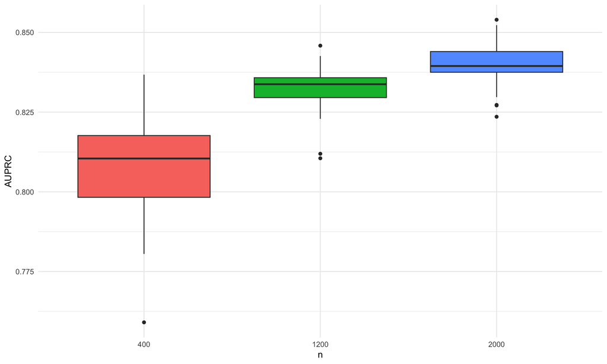

#### Interaction Recovery Plot

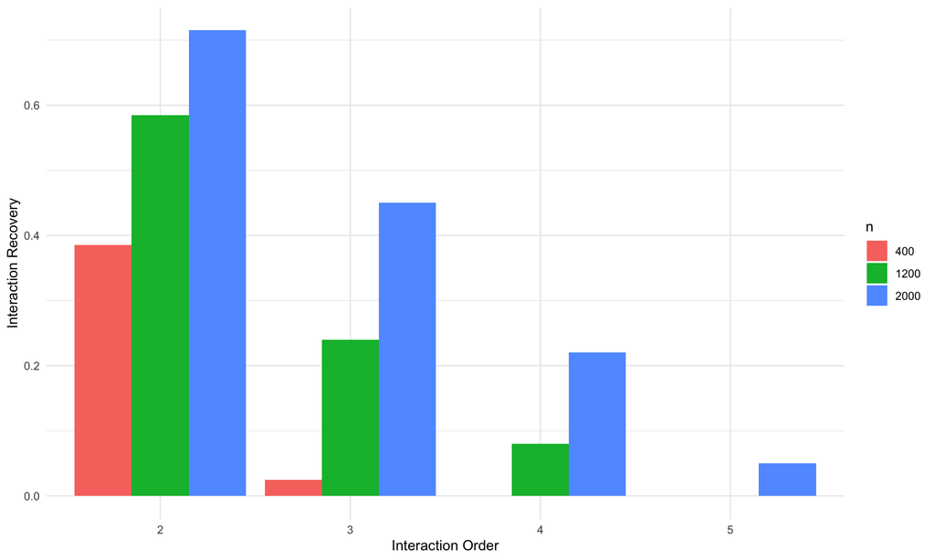

#### Interaction Stability Plot

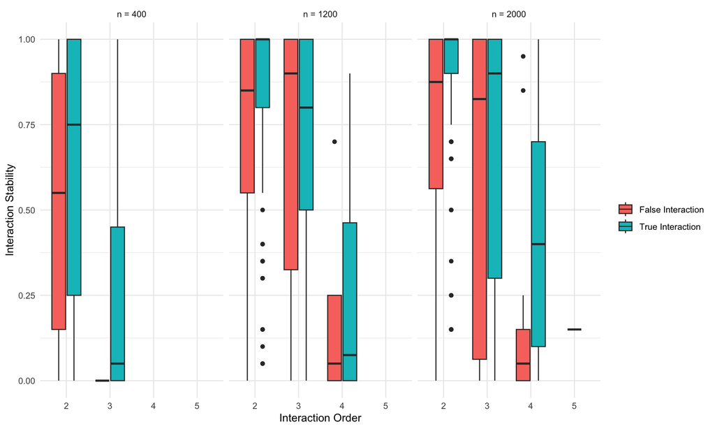

**Parameter Values**

```
## $dgp
## $dgp$`Enhancer LSS with RF Noise`
## $dgp$`Enhancer LSS with RF Noise`$n
## [1]  400 1200 2000
##
##
##
## $method
## list()
```